# lesson09.R

jonkq

2019-12-12

## Assignment Set 3: Lesson 9

Add R Code under the questions. If you are done, ‘knit’ the document, commit and push to GitHub. You can use GitHub Pages if you like, add links to README.md to make it easier to find the pretty version.

Back to the `CASchools` dataset on test performance, school characteristics and student demographic backgrounds for school districts in California. As before, we will enhance the dataset by defining two new variables, `student_teacher_ratio`, the student-teacher ratio, and `test_score`, an average of two underlying test scores:

```r
library(dplyr)
```

```r
library(ggplot2)
library(AER)
data(CASchools)

caschools <-
  CASchools %>%
  as_tibble() %>%
  mutate(student_teacher_ratio = students / teachers) %>%
  mutate(test_score = (read + math) / 2) %>%
  select(-read, -math, -students, -teachers, -district, -school, -county, -grades)

caschools
```

```
## # A tibble: 420 x 8
##    calworks  lunch computer expenditure income english student_teacher~
##       <dbl>  <dbl>    <dbl>       <dbl>  <dbl>   <dbl>            <dbl>
##  1    0.510   2.04       67       6385.  22.7     0                17.9
##  2   15.4    47.9       101       5099.   9.82    4.58             21.5
##  3   55.0    76.3       169       5502.   8.98   30.0              18.7
##  4   36.5    77.0        85       7102.   8.98    0                17.4
##  5   33.1    78.4       171       5236.   9.08   13.9              18.7
##  6   12.3    87.0        25       5580.  10.4    12.4              21.4
##  7   12.9    94.6        28       5253.   6.58   68.7              19.5
##  8   18.8   100          66       4566.   8.17   47.0              20.9
##  9   32.2    93.1        35       5356.   7.39   30.1              19.9
## 10   79.0    87.3         0       5036.  11.6    40.3              20.8
## # ... with 410 more rows, and 1 more variable: test_score <dbl>
```

1. Separate the data set into a training and a test set. Make sure the training set contains 75% of the available observations.

```r
set.seed(75)
caschools_train <- sample_n(caschools, 315)
caschools_test <- anti_join(caschools, caschools_train)
```

2. Build a decision tree to predict `student_teacher_ratio`, using all variables in `caschools_train`. Use the defaults of `rpart`. Draw the resulting decision tree. Store the model as `m_tree`.

```r
library(rpart)
m_tree <- rpart(student_teacher_ratio ~ ., data = caschools_train, method = "anova", maxdepth = 1)
m_tree
```

```
## n= 315
##
## node), split, n, deviance, yval
##       * denotes terminal node
##
## 1) root 315 1072.3400 19.61519
##   2) expenditure>=5618.565 79  212.7569 17.97434 *
##   3) expenditure< 5618.565 236  575.6832 20.16446 *
```

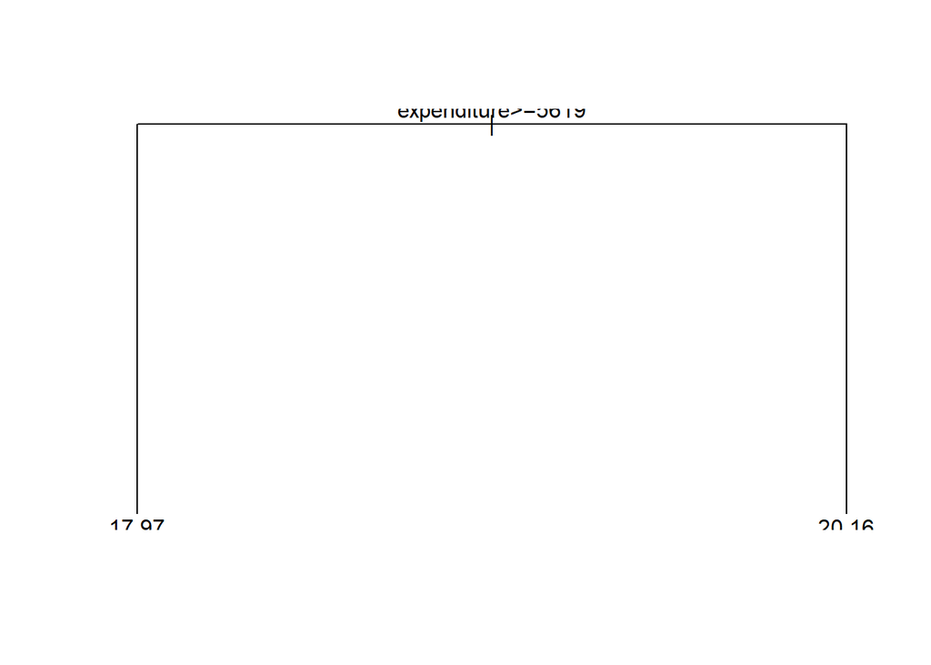

```r
plot(m_tree)
text(m_tree)
```

```r
summary(m_tree)
```

```
## Call:
## rpart(formula = student_teacher_ratio ~ ., data = caschools_train,
##     method = "anova", maxdepth = 1)
##   n= 315
##
##          CP nsplit rel error    xerror       xstd
## 1 0.2647477      0 1.0000000 1.0129063 0.09492166
## 2 0.0100000      1 0.7352523 0.8060062 0.07395125
##
## Variable importance
## expenditure  test_score      income       lunch    calworks
##          71           9           8           7           5
##
## Node number 1: 315 observations,    complexity param=0.2647477
##   mean=19.61519, MSE=3.404252
##   left son=2 (79 obs) right son=3 (236 obs)
##   Primary splits:
##       expenditure < 5618.565 to the right, improve=0.26474770, (0 missing)
##       english     < 4.549731 to the left,  improve=0.11260390, (0 missing)
##       lunch       < 3.73075  to the left,  improve=0.10252960, (0 missing)
##       income      < 27.71148 to the right, improve=0.09109280, (0 missing)
##       test_score  < 689.95   to the right, improve=0.08735049, (0 missing)
##   Surrogate splits:
##       test_score < 689.95   to the right, agree=0.781, adj=0.127, (0 split)
##       income     < 25.48836 to the right, agree=0.778, adj=0.114, (0 split)
##       lunch      < 3.6761   to the left,  agree=0.775, adj=0.101, (0 split)
##       calworks   < 0.6823   to the left,  agree=0.768, adj=0.076, (0 split)
##
## Node number 2: 79 observations
##   mean=17.97434, MSE=2.693125
##
## Node number 3: 236 observations
##   mean=20.16446, MSE=2.439336
```

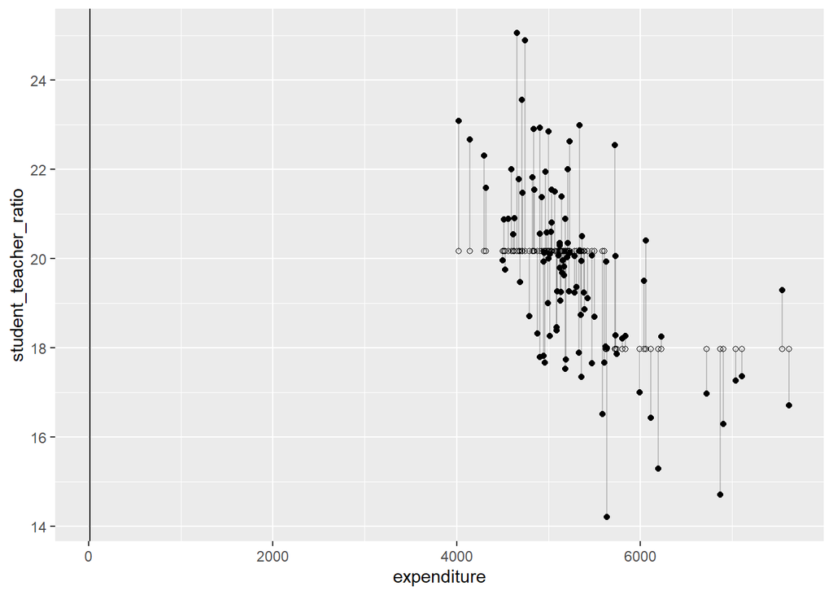

```r
caschools_test %>%
  mutate(predict = predict(m_tree, newdata = caschools_test)) %>%
  ggplot(aes(x = expenditure, y = student_teacher_ratio)) +
  geom_point() +
  geom_point(mapping = aes(y = predict), shape = 21) +
  geom_segment(mapping = aes(xend = expenditure, yend = predict), alpha = 0.2) +
  geom_vline(aes(xintercept = 9.95))
```

3. From the documentation, `?rpart`, can you figure out how the depth of a tree is determined? Which one is the most important variable?

```r
?rpart
```

```
## starting httpd help server ... done
```

“maxdepth” is a special argument of rpart function and its documentation can be found under “rpart.control” in ?rpart.

The most important variable in the decision tree model is “expenditure” (summary(m_tree)) 4. Estimate an OLS model to predict `student_teacher_ratio`, using all variables in `caschools_train`. Which one is the most important variable? Store the model as `m_ols`.

```r
m_ols <- lm(student_teacher_ratio ~ ., data = caschools_train)
summary(m_ols)
```

```
##
## Call:
## lm(formula = student_teacher_ratio ~ ., data = caschools_train)
##
## Residuals:
##     Min      1Q  Median      3Q     Max
## -3.5892 -0.7543 -0.0487  0.7552  4.3384
##
## Coefficients:
##               Estimate Std. Error t value Pr(>|t|)
## (Intercept) 35.6916956  6.2602606   5.701 2.79e-08 ***
## calworks    -0.0115304  0.0121478  -0.949 0.343275
## lunch       -0.0032194  0.0078332  -0.411 0.681366
## computer     0.0007423  0.0001983   3.744 0.000217 ***
## expenditure -0.0016890  0.0001428 -11.830  < 2e-16 ***
## income      -0.0091098  0.0180364  -0.505 0.613867
## english      0.0116138  0.0069868   1.662 0.097485 .
## test_score  -0.0107671  0.0094675  -1.137 0.256312
## ---
## Signif. codes:  0 '***' 0.001 '**' 0.01 '*' 0.05 '.' 0.1 ' ' 1
##
## Residual standard error: 1.385 on 307 degrees of freedom
## Multiple R-squared:  0.4511, Adjusted R-squared:  0.4386
## F-statistic: 36.05 on 7 and 307 DF,  p-value: < 2.2e-16
```

5. Grow a random forest to predict `student_teacher_ratio`, using all variables in `caschools_train`. Use the defaults of `randomForest`. Store the model as `m_forest`.

```r
library(randomForest)
```

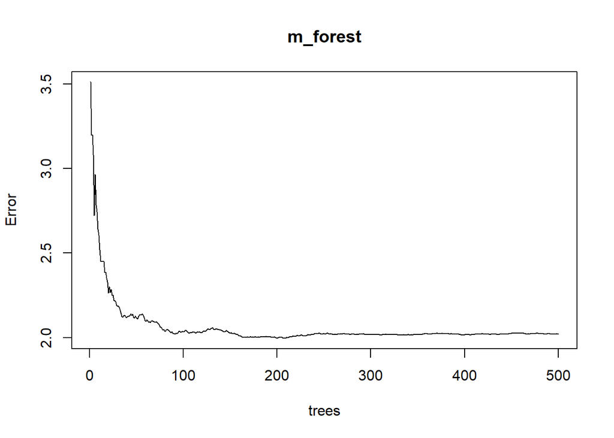

```r
set.seed(01)

m_forest <- randomForest(student_teacher_ratio ~ ., data = caschools_train)
plot(m_forest)
```

6. Plot the variable importance for `m_forest`. Which one is the most imporant?

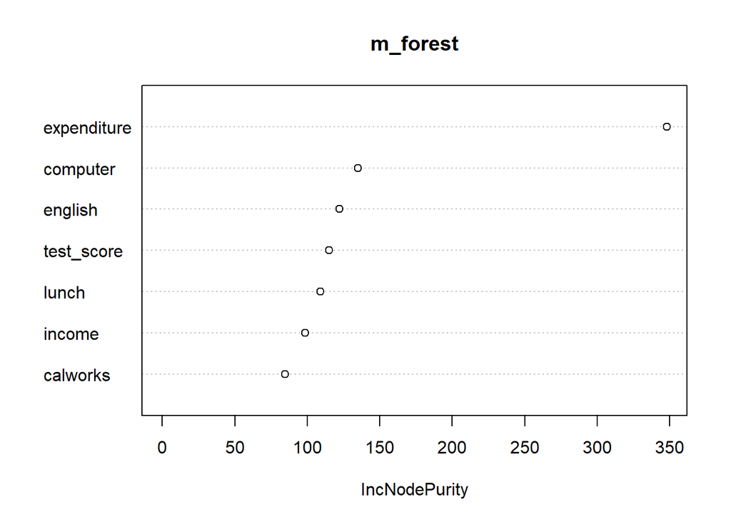

```r
varImpPlot(m_forest)
```

7. Using the test data, can you compute RMSE measures for `m_ols`, `m_tree`, and `m_forest`? Which performs best?

```r
rmse_tree <- sqrt(mean((caschools_test$student_teacher_ratio - predict(m_tree, newdata = caschools_test))^2))
rmse_ols <- sqrt(mean((caschools_test$student_teacher_ratio - predict(m_ols, newdata = caschools_test))^2))
rmse_forest <- sqrt(mean((caschools_test$student_teacher_ratio - predict(m_forest, newdata = caschools_test))^2))
```